# Replication File for A New Construction of Evidence Factors in an Observational Study of Light Daily Alcohol Consumption and Longevity

2026-01-13

This is a replication file for “A New Construction of Evidence Factors in an Observational Study of Light Daily Alcohol Consumption and Longevity”.

Parts of this file are in the documentation for the R package alcoholSurv at CRAN. You MUST install that package to run this replication file.

Early parts of this file replicate the analysis. They run fairly quickly. Later parts replicate the design sensitivity and simulation calculations – they are much slower.

The replication requires the following R packages: alcoholSurv, senstrat, survival, coin, xtable.

In addition, to run this replication file, you need the talc.csv file that is part of this supplementary material. The replication file will attempt to read and slightly structure the talc.csv file; so, if you don’t have the file or if R cannot find the file, you are likely to get an error at that attempted read. The talc.csv file is mostly the same as the alcoholSurv file from the alcoholSurv package, but it adds medication information from NHANES to produce Figure 3 and Table 1 for Section 5.2.

This section replicates Figures 1 and 2.

```r
library(alcoholSurv)
```

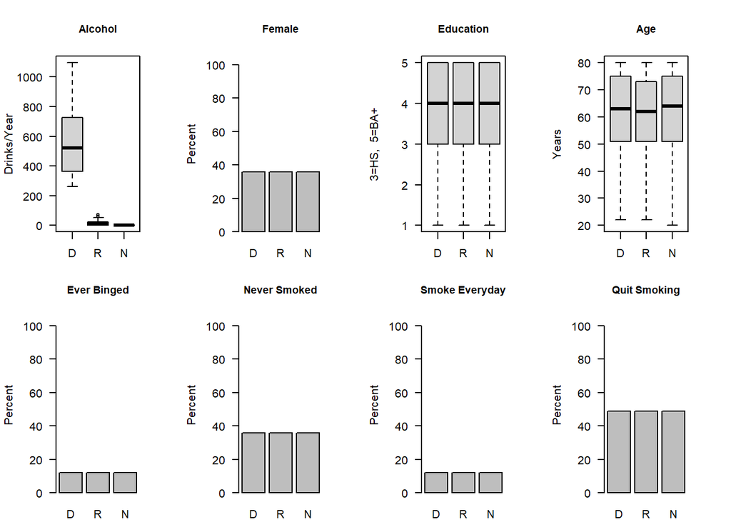

```r
data("alcoholSurv")
par(mfrow=c(2,4),mar=c(2,4,4,3)+.1)
g<-as.integer(alcoholSurv$gDrinks)
g<-factor(g,levels=1:3,labels=c("D","R","N"),ordered=TRUE)
boxplot((alcoholSurv$aDays*alcoholSurv$aDrinks)~g,ylab="Drinks/Year",las=1,main="Alcohol",
        xlab="",cex.main=.9)
barplot(round(tapply(alcoholSurv$female,g,mean)*100),ylim=c(0,105),
        ylab="Percent",main="Female",las=1,cex.main=.9)
boxplot(alcoholSurv$education~g,ylab="3=HS,  5=BA+",las=1,main="Education",
        xlab="",cex.main=.9)
boxplot(alcoholSurv$age~g,ylab="Years",las=1,main="Age",
        xlab="",cex.main=.9)
barplot(round(tapply(alcoholSurv$aEverBinge,g,mean)*100),ylim=c(0,105),
        ylab="Percent",main="Ever Binged",las=1,cex.main=.9)
barplot(round(tapply(alcoholSurv$smoke=="Never",g,mean)*100),ylim=c(0,105),
        ylab="Percent",main="Never Smoked",las=1,cex.main=.9)
barplot(round(tapply(alcoholSurv$smoke=="Everyday",g,mean)*100),ylim=c(0,105),
        ylab="Percent",main="Smoke Everyday",las=1,cex.main=.9)
barplot(round(tapply(alcoholSurv$smoke=="NotNow",g,mean)*100),ylim=c(0,105),
        ylab="Percent",main="Quit Smoking",las=1,cex.main=.9)

years<-alcoholSurv$time/12
library(survival)
```

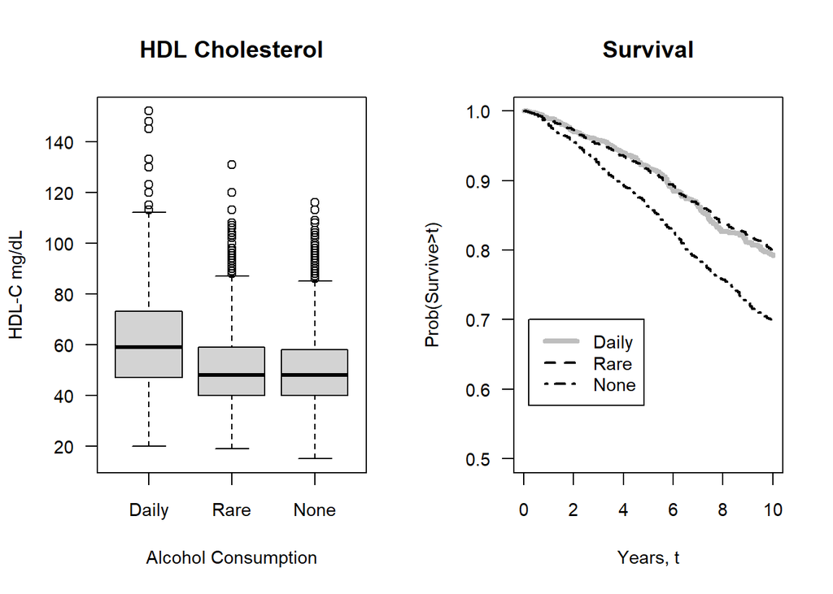

```r
years<-Surv(years,alcoholSurv$mortstat)
par(mfrow=c(1,2),mar=c(5,4,4,2)+.1)
boxplot(alcoholSurv$hdl~alcoholSurv$gDrinks,las=1,main="HDL Cholesterol",
        ylab="HDL-C mg/dL",xlab="Alcohol Consumption",cex.axis=.9,cex.lab=.9)
plot(survfit(years~g),ylim=c(.5,1),ylab="Prob(Survive>t)",xlab="Years, t",
     xlim=c(0,10),lty=c(1,2,4),lwd=c(4,2,2),cex.lab=.9,main="Survival",
     col=c("grey","black","black"),cex.axis=.9,las=1)
legend(.2,.7,c("Daily","Rare","None"),lty=c(1,2,4),lwd=c(4,2,2),
       col=c("grey","black","black"),cex=.9)
```

XXXXXXXXXXXXXXXXXXXXXXXXXXXXXXXXXXXXXXXXXXXXXXXXXXXXXXXXXXXXXX

This section replicates the main inferences reported in Section 5.1. This portion of the replication is also an example in the R package alcoholSurv.

As suggested by O’Brien and Fleming (1987) Biometrics 43, 169-180, a block without a death is omitted from the permutation test. In a block without a death, the log-rank scores vary only because of unequal censoring times.

```r
library(alcoholSurv)
data("alcoholSurv")

library(survival)
sv<-survival::Surv(alcoholSurv$time,alcoholSurv$mortstat)
svlogrank<-coin::logrank_trafo(sv, ties.method = "average-scores")
names(svlogrank)<-alcoholSurv$treated

selectBlock<-function(grps,mortstat){
  # Return a logical vector picking out blocks with at least one
  # death in among alcoholSurv$dGroups in grps
  colnums<-NULL
  if (is.element("Daily",grps)) colnums<-c(colnums,1)
  if (is.element("Rare",grps)) colnums<-c(colnums,c(2,3))
  if (is.element("None",grps)) colnums<-c(colnums,c(4,5))
  mort<-t(matrix(mortstat,5,1130))
  who<-apply(mort[,colnums],1,sum)>0 # at least one death
  who<-as.vector(rbind(who,who,who,who,who))
  who&is.element(alcoholSurv$gDrinks,grps)
}

who<-selectBlock(c("Daily","Rare","None"),alcoholSurv$mortstat)
senstrat::senstrat(svlogrank[who],alcoholSurv$z[who],as.numeric(alcoholSurv$mset)[who],gamma=1,detail=TRUE)
```

```
## $Conclusion
## [1] "The null hypothesis is rejected at level  0.05  in the presence of a bias of at most Gamma =  1 ."
##
## $LinearBoundResult
##       P-value       Deviate     Statistic      Expected      Variance
##  1.373036e-03  2.994820e+00 -8.803215e+01 -1.245006e+02  1.482841e+02
##         Gamma
##  1.000000e+00
##
## $Separable
##       P-value       Deviate     Statistic      Expected      Variance
##  1.373036e-03  2.994820e+00 -8.803215e+01 -1.245006e+02  1.482841e+02
##         Gamma
##  1.000000e+00
##
## $Description
##  Strata Treated Control
##     609     609    2436
##
## $Remark
## [1] "In testing at level  0.05  in the presence of a bias of at most Gamma =  1 , the linear bound and the separable approximation agree. "
##
## $StrataUse
## [1] "All  609  strata were used."
##
## $lambda
##           Separable Linear Taylor bound
##            -16.4388            -16.4388
```

```r
#
#  As suggested by O'Brien and Fleming (1987) Biometrics 43, 169-180,
#  a block without a death is omitted from the permutation test.
#  In a block without a death, the log-rank scores vary only
#  because of unequal censoring times.
#
lr<-svlogrank[who]
names(lr)<-alcoholSurv$SEQN[who]
mlr<-t(matrix(lr,5,length(lr)/5))
mwho<-t(matrix(as.numeric(names(lr)),5,length(lr)/5))
rownames(mlr)<-mwho[,1]


hdl<-t(matrix(alcoholSurv$hdl,5,1130))


#
#  Evidence factor analysis for HDL-C
#
wgtRankCef(hdl,colGroups = c("D","R","R","N","N"),gammas=5.5,trunc=1,phi="u878")
```

```
## $tProd.pval
## [1] 0.0005882163
##
## $pvals
##           R           N
## 0.038944838 0.001395945
##
## $blocks.used
##   R   N
## 246 272
##
## $treated.max
##   R   N
## 211 230
```

```r
wgtRankCef(hdl,colGroups = c("D","R","R","N","N"),gammas=8.25,trunc=1,phi="u878")
```

```
## $tProd.pval
## [1] 0.04786306
##
## $pvals
##          R          N
## 0.29448380 0.02803872
##
## $blocks.used
##   R   N
## 246 272
##
## $treated.max
##   R   N
## 211 230
```

```r
#
#  Evidence factor analysis for survival
#
wgtRankCef(mlr,colGroups = c("D","R","R","N","N"),gammas=5/3,trunc=1,phi="none")
```

```
## $tProd.pval
## [1] 0.04764404
##
## $pvals
##           R           N
## 0.859038082 0.009558732
##
## $blocks.used
##   R   N
##  96 118
##
## $treated.max
##  R  N
## 54 84
```

XXXXXXXXXXXXXXXXXXXXXXXXXXXXXXXXXXXXXXXXXXXXXXXXXXXXXXXXXXXXXXXXXXX

This section reproduces the medication analysis in Table 1 and Figure 3, as discussed in Section 5.2. See the discussion of the talc.csv file at the top of this script.

```r
library(xtable)
talc<-read.csv("talc.csv")
talc$tgrp<-factor(talc$tgrp,levels=c("D","Rc","Ro","Nc","No"),
     labels=c("aD","bRc","cRo","dNc","dNo"))
talc$tgrp2<-factor(talc$tgrp2,levels=c("D","Rc","Nc","Ro","No"),ordered=TRUE)
drcnt<-tapply(talc$RXDCOUNT,talc$gDrinks,quantile,
     c(.25,.5,.75,.8,.85,.9,.95,.975))


drcntTab<-rbind(drcnt$Daily,drcnt$Rare,drcnt$None)
rownames(drcntTab)<-c("Daily","Rare","None")
xtable::xtable(drcntTab,digits=0)
```

```
## % latex table generated in R 4.4.1 by xtable 1.8-4 package
## % Tue Jan 13 17:22:37 2026
## \begin{table}[ht]
## \centering
## \begin{tabular}{rrrrrrrrr}
##   \hline
##  & 25\% & 50\% & 75\% & 80\% & 85\% & 90\% & 95\% & 97.5\% \\
##   \hline
## Daily & 0 & 2 & 4 & 4 & 5 & 6 & 8 & 10 \\
##   Rare & 0 & 2 & 5 & 5 & 6 & 7 & 9 & 11 \\
##   None & 0 & 3 & 6 & 6 & 7 & 8 & 10 & 12 \\
##    \hline
## \end{tabular}
## \end{table}
```

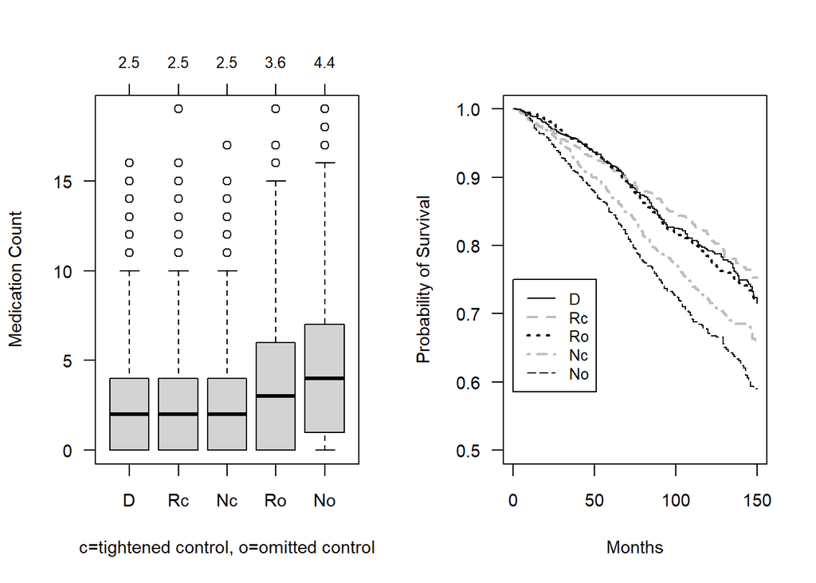

```r
par(mfrow=c(1,2))

boxplot(talc$RXDCOUNT~talc$tgrp2,las=1,cex.axis=.9,cex.lab=.9,
        ylab="Medication Count",xlab="c=tightened control, o=omitted control")

axis(3,at=1:5,labels=round(tapply(talc$RXDCOUNT,talc$tgrp2,mean),1),
    cex.axis=.8)

library(survival)
st<-Surv(talc$time,talc$mortstat)
col<-c("black","grey","black","grey","black")
lwd<-c(1,2,2,2,1)
plot(survfit(st~talc$tgrp),col=col,
     lty=1:5,lwd=lwd,las=1,xlim=c(0,150),
     ylab="Probability of Survival",xlab="Months",ylim=c(.5,1),
     cex.axis=.9,cex.lab=.9)

legend(0,.75,c("D","Rc","Ro","Nc","No"),col=col,lty=1:5,lwd=lwd,cex=.8)
```

```r
rm(col,lwd)

Rc<-1*(talc$tgrp2=="Rc")
Ro<-1*(talc$tgrp2=="Ro")
Nc<-1*(talc$tgrp2=="Nc")
No<-1*(talc$tgrp2=="No")
coxph(st~Rc+Ro+Nc+No+strata(talc$mset))
```

```
## Call:
## coxph(formula = st ~ Rc + Ro + Nc + No + strata(talc$mset))
##
##        coef exp(coef) se(coef)      z        p
## Rc -0.09966   0.90515  0.10463 -0.952    0.341
## Ro  0.06149   1.06342  0.10238  0.601    0.548
## Nc  0.39166   1.47943  0.09738  4.022 5.77e-05
## No  0.62056   1.85998  0.09420  6.588 4.47e-11
##
## Likelihood ratio test=79.29  on 4 df, p=2.464e-16
## n= 5650, number of events= 1271
```

XXXXXXXXXXXXXXXXXXXXXXXXXXXXXXXXXXXXXXXXXXXXXXXXXXXXXXXXXXXXXXXXXXX

This section replicates design sensitivity calculations, for example, those in Table 2. It takes some time.

```r
ds<-function(taus,ns,df=Inf,m=NULL,m1=NULL,m2=NULL,noether=NULL,
             maxGamma=15,brief=TRUE){
  #
  # Check input
  #
  stopifnot(is.logical(brief))
  stopifnot(length(ns)>=2)
  stopifnot(all(ns>0))
  stopifnot(length(taus)==length(ns))
  stopifnot((df==-1)|(df>=3))
  if (is.null(m)&(is.null(noether))){
    warning("Statistic not specified, defaulting to m=m1=m2=1")
    m<-1
    m1<-1
    m2<-1
  }
  else if ((!is.null(m))&(!is.null(noether)))
    stop("(m,m1,m2) and noether specify two different statistics.")
  else if ((is.null(m))&(!is.null(noether))) stopifnot((noether>=0)&(noether<1))
  else stopifnot((m>=m2)&(m2>=m1)&(m1>0))
  #
  # Record the situation
  sit1<-rbind(ns,taus)
  colnames(sit1)<-1:length(ns)
  if (is.null(noether)){
    sit2<-c(m,m1,m2,df)
    names(sit2)<-c("m","m1","m2","df")
  }
  else {
    sit2<-c(noether,df)
    names(sit2)<-c("noether","df")
  }
  #
  # Define functions used later
  #
  # Define the score function for absolute ranks in [0,1]
  multrnksU <- function(pk) {
    n <- length(pk)
    q <- rep(0, n)
    q <- rep(0, n)
    for (l in m1:m2) {
      q <- q + (l * choose(m, l) * (pk^(l - 1)) * ((1 -
                                                      pk)^(m - l)))
    }
    q
  }
  noetherf<-function(pk){1*(pk>=noether)}
  # psi is the weight function for the block ranges
  if (is.null(m)) psi<-noetherf
  else psi<-multrnksU
  #
  #  Define distributions and densities in each group
  if (df==Inf) deltas<-taus*sqrt(2)
  else if (df==-1) deltas<-taus*sqrt(2)*sqrt(pi*pi/3)
  else deltas<-taus*sqrt(2)*sqrt(df/(df-2))
  K<-length(ns)
  if (df==Inf){
    g<-function(y){dnorm(y)}
    G<-function(y){pnorm(y)}
  }
  else if (df==-1){
    g<-function(y){dlogis(y)}
    G<-function(y){plogis(y)}
  }
  else{
    g<-function(y){dt(y,df)}
    G<-function(y){pt(y,df)}
  }
  #
  #
  cab<-function(a,b,v,y){
    between<-G((y+v)-deltas)-G(y-deltas)
    nsa<-ns
    if (a!=b) {
      nsa[c(a,b)]<-nsa[c(a,b)]-1
      ns[a]*ns[b]*(prod(between^nsa))*g((y+v)-deltas[a])*g(y-deltas[b])
    }
    else {
      if (ns[a]==1) 0
      else {
        nsa[a]<-nsa[a]-2
        ns[a]*(ns[a]-1)*(prod(between^nsa))*g((y+v)-deltas[a])*g(y-deltas[a])
      }
    }
  }
  Cab1<-function(a,b,v){
    # Density at range v when group a has max and group b has min
    f<-function(y){
      o<-NULL
      for (i in 1:length(y)) o<-c(o,cab(a,b,v,y[i]))
      o
    }
    integrate(f,-Inf,Inf)$value
  }
  Cab<-function(a,b){
    # Probability group a has max and group b has min
    f1<-function(v){Cab1(a,b,v)}
    f<-Vectorize(f1)
    integrate(f,0,Inf)$value
  }

  crange<-function(v,y){
    o<-0
    for (a in 1:K) for (b in 1:K) {
      o<-o+cab(a,b,v,y)
    }
    o
  }
  Crange1<-function(v){
    # Density of the range of sum(ns) observations
    f<-function(y){
      o<-NULL
      for (i in 1:length(y)) o<-c(o,crange(v,y[i]))
      o[is.nan(o)]<-0
      o
    }
    integrate(f,-Inf,Inf)$value
  }
  Crange<-Vectorize(Crange1)
  #
  # Cumulative distribution of the range of sum(ns) observations
  CumRange1<-function(w){integrate(Crange,0,w)$value}
  #
  # Begin computations
  #
  p1K<-Cab(1,K)  # prob group 1 contains max, group K contains min
  pK1<-Cab(K,1)  # prob group K contains max, group 1 contains min
  pTotal<-p1K+pK1 # prob groups 1 and K contain the decisive pair
  #
  #  Determine favorable expectation
  #
  int1<-function(v){(Cab1(1,K,v)/pTotal)*psi(CumRange1(v))}
  int<-Vectorize(int1)
  expectFavorable<-integrate(int,0,Inf)$value
  #
  #  Determine the gamma-free constant e1 in the unfavorable expectation
  #
  intBoth1<-function(v){((Cab1(1,K,v)+Cab1(K,1,v))/pTotal)*psi(CumRange1(v))}
  intBoth<-Vectorize(intBoth1)
  e1<-integrate(intBoth,0,Inf)$value
  f<-function(gammas){
    (e1*gammas/(1+gammas))-expectFavorable
  }
  # Solve for design sensitivity ds
  ds<-uniroot(f,c(1,maxGamma))$root
  #
  # Prepare output
  probabilities<-c(p1K,pK1,pTotal)
  names(probabilities)<-c("1 is max","K is max","(1,K) is Decisive")
  if (brief) list(ds=ds,probabilities=probabilities)
  else list(ds=ds,probabilities=probabilities,expectFavorable=expectFavorable,
            expectUnfavorable=f(ds)+expectFavorable,situation=sit1,statistic=sit2)
}




dsTable131<-matrix(NA,6,2)
colnames(dsTable131)<-c("C1","C2")
rownames(dsTable131)<-c("Case1N","Case1L","Case2N","Case2L","Case3N","Case3L")

temp<-ds(c(1/3,0,0),c(1,3,1),m=8,m1=7,m2=8)
dsTable131[1,1]<-temp$ds
dsTable131[1,2]<-temp$ds

temp<-ds(c(1/3,0,0),c(1,3,1),m=8,m1=7,m2=8,df=-1)
dsTable131[2,1]<-temp$ds
dsTable131[2,2]<-temp$ds

temp<-ds(c(5/12,5/12,0),c(1,3,1),m=8,m1=7,m2=8)
dsTable131[3,1]<-1
dsTable131[3,2]<-temp$ds

temp<-ds(c(5/12,5/12,0),c(1,3,1),m=8,m1=7,m2=8,df=-1)
dsTable131[4,1]<-1
dsTable131[4,2]<-temp$ds

temp<-ds(c(5/12,0,2/12),c(1,3,1),m=8,m1=7,m2=8)
dsTable131[5,1]<-temp$ds
temp<-ds(c(5/12,2/12,0),c(1,3,1),m=8,m1=7,m2=8)
dsTable131[5,2]<-temp$ds

temp<-ds(c(5/12,0,2/12),c(1,3,1),m=8,m1=7,m2=8,df=-1)
dsTable131[6,1]<-temp$ds
temp<-ds(c(5/12,2/12,0),c(1,3,1),m=8,m1=7,m2=8,df=-1)
dsTable131[6,2]<-temp$ds

dsTable131JustOne<-matrix(NA,6,2)
colnames(dsTable131JustOne)<-c("justC1","justC2")
rownames(dsTable131JustOne)<-c("Case1N","Case1L","Case2N","Case2L","Case3N","Case3L")

temp<-ds(c(1/3,0),c(1,2),m=8,m1=7,m2=8)
dsTable131JustOne[1,1]<-temp$ds
dsTable131JustOne[1,2]<-temp$ds

temp<-ds(c(1/3,0),c(1,2),m=8,m1=7,m2=8,df=-1)
dsTable131JustOne[2,1]<-temp$ds
dsTable131JustOne[2,2]<-temp$ds

temp<-ds(c(5/12,0),c(1,2),m=8,m1=7,m2=8)
dsTable131JustOne[3,1]<-1
dsTable131JustOne[3,2]<-temp$ds

temp<-ds(c(5/12,0),c(1,2),m=8,m1=7,m2=8,df=-1)
dsTable131JustOne[4,1]<-1
dsTable131JustOne[4,2]<-temp$ds

temp<-ds(c(5/12,2/12),c(1,2),m=8,m1=7,m2=8)
dsTable131JustOne[5,1]<-temp$ds
temp<-ds(c(5/12,0),c(1,2),m=8,m1=7,m2=8)
dsTable131JustOne[5,2]<-temp$ds

temp<-ds(c(5/12,2/12),c(1,2),m=8,m1=7,m2=8,df=-1)
dsTable131JustOne[6,1]<-temp$ds
temp<-ds(c(5/12,0),c(1,2),m=8,m1=7,m2=8,df=-1)
dsTable131JustOne[6,2]<-temp$ds

rm(temp)

xtable::xtable(cbind(dsTable131,dsTable131JustOne)[c(1,2,5,6,3,4),],digits=1)
```

```
## % latex table generated in R 4.4.1 by xtable 1.8-4 package
## % Tue Jan 13 17:56:34 2026
## \begin{table}[ht]
## \centering
## \begin{tabular}{rrrrr}
##   \hline
##  & C1 & C2 & justC1 & justC2 \\
##   \hline
## Case1N & 5.0 & 5.0 & 3.8 & 3.8 \\
##   Case1L & 4.2 & 4.2 & 3.5 & 3.5 \\
##   Case3N & 3.3 & 7.4 & 2.7 & 5.3 \\
##   Case3L & 2.9 & 6.0 & 2.6 & 4.8 \\
##   Case2N & 1.0 & 7.5 & 1.0 & 5.3 \\
##   Case2L & 1.0 & 5.9 & 1.0 & 4.8 \\
##    \hline
## \end{tabular}
## \end{table}
```

XXXXXXXXXXXXXXXXXXXXXXXXXXXXXXXXXXXXXXXXXXXXXXXXXXXXXXXXXXXXXXXXXXXXXXXX

This final section reproduces the simulation in the on-line supplemental appendix. It takes some time.

```r
library(alcoholSurv)

sim1<-function(I,J=5,omega=c(1/3,0,0,0,0),dist="N"){
  stopifnot((dist=="N")|(dist=="L")|(dist=="t5"))
  stopifnot(J==length(omega))
  if (dist=="N"){
    y<-matrix(rnorm(I*J),I,J)
    mult<-sqrt(2)
  }
  else if (dist=="t5"){
    y<-matrix(rt(I*J,5),I,J)
    mult<-sqrt(2)*sqrt(5/3)
  }
  else {
    y<-matrix(rlogis(I*J),I,J)
    mult<-sqrt(2)*sqrt(pi*pi/3)
  }
  for (j in 1:J) y[,j]<-y[,j]+omega[j]*mult
  y
}

sim<-function(reps,I,J,omega,colGroups=c("T","C1","C1","C2","C2"),
              gamma=1,dist="N",phi="u878"){
  o<-matrix(NA,reps,8)
  rownames(o)<-1:reps
  colnames(o)<-c("TC1","TC2","Fisher","Truncated","TC1C2",
                 "justRC1","justRC2","Bonf")
  nm<-paste("I",I,"J",J,dist,phi,"Gamma",gamma,sep="")
  for (i in 1:length(omega)) nm<-paste(nm,round(omega[i],2))
  names(dimnames(o))<-c("",nm)
  ugroups<-unique(colGroups)
  who1<-is.element(colGroups,ugroups[1:2])
  who2<-is.element(colGroups,ugroups[c(1,3)])
  altGroups0<-c(colGroups[1],rep(colGroups[2],J-1))
  altGroups1<-colGroups[who1]
  altGroups2<-colGroups[who2]
  for (l in 1:reps){
    y<-sim1(I,J=J,omega=omega,dist=dist)
    lo<-wgtRankCef(y,colGroups=colGroups,phi=phi,gamma=gamma)
    o[l,1]<-lo$pvals[1]
    o[l,2]<-lo$pvals[2]
    if (min(o[l,1],o[l,2])==0){
      o[l,3]<-0
      o[l,4]<-0
    }
    else{
      o[l,3]<-sensitivitymv::truncatedP(c(o[l,1],o[l,2]),trunc=1)
      o[l,4]<-sensitivitymv::truncatedP(c(o[l,1],o[l,2]),trunc=0.2)
    }
    lo2<-wgtRankCef(y,colGroups=altGroups0,phi=phi,gamma=gamma)
    o[l,5]<-lo2$pvals[1]
    lo2<-wgtRankCef(y[,who1],colGroups=altGroups1,phi=phi,gamma=gamma)
    o[l,6]<-lo2$pvals[1]
    lo2<-wgtRankCef(y[,who2],colGroups=altGroups2,phi=phi,gamma=gamma)
    o[l,7]<-lo2$pvals[1]
    o[l,8]<-min(1,2*min(o[l,6],o[l,7]))
  }
  o
}

reps<-2500
ss<-1000
uphi<-"u878"
ugamma<-3
set.seed(12345)
LI1000J5bothGamma3<-sim(reps,ss,5,c(4/12,0,0,0,0),dist="L",gamma=ugamma,phi=uphi)
set.seed(12345)
NI1000J5bothGamma3<-sim(reps,ss,5,c(4/12,0,0,0,0),dist="N",gamma=ugamma,phi=uphi)
set.seed(12345)
LI1000J5oneGamma3<-sim(reps,ss,5,c(5/12,5/12,5/12,0,0),dist="L",gamma=ugamma,phi=uphi)
set.seed(12345)
NI1000J5oneGamma3<-sim(reps,ss,5,c(5/12,5/12,5/12,0,0),dist="N",gamma=ugamma,phi=uphi)
set.seed(12345)
LI1000J5halfGamma3<-sim(reps,ss,5,c(5/12,2/12,2/12,0,0),dist="L",gamma=ugamma,phi=uphi)
set.seed(12345)
NI1000J5halfGamma3<-sim(reps,ss,5,c(5/12,2/12,2/12,0,0),dist="N",gamma=ugamma,phi=uphi)
rm(uphi,ugamma,ss,reps)

powerTabI1000Gamma3<-rbind(apply(NI1000J5bothGamma3<=0.05,2,mean),
                           apply(LI1000J5bothGamma3<=0.05,2,mean),
                           apply(NI1000J5halfGamma3<=0.05,2,mean),
                           apply(LI1000J5halfGamma3<=0.05,2,mean),
                           apply(NI1000J5oneGamma3<=0.05,2,mean),
                           apply(LI1000J5oneGamma3<=0.05,2,mean)
)
rownames(powerTabI1000Gamma3)<-c("Nboth","Lboth","Nhalf","Lhalf","None","Lone")

reps<-2500
ss<-2000
uphi<-"u878"
ugamma<-3.5
set.seed(12345)
LI2000J5bothGamma35<-sim(reps,ss,5,c(4/12,0,0,0,0),dist="L",gamma=ugamma,phi=uphi)
set.seed(12345)
NI2000J5bothGamma35<-sim(reps,ss,5,c(4/12,0,0,0,0),dist="N",gamma=ugamma,phi=uphi)
set.seed(12345)
LI2000J5oneGamma35<-sim(reps,ss,5,c(5/12,5/12,5/12,0,0),dist="L",gamma=ugamma,phi=uphi)
set.seed(12345)
NI2000J5oneGamma35<-sim(reps,ss,5,c(5/12,5/12,5/12,0,0),dist="N",gamma=ugamma,phi=uphi)
set.seed(12345)
LI2000J5halfGamma35<-sim(reps,ss,5,c(5/12,2/12,2/12,0,0),dist="L",gamma=ugamma,phi=uphi)
set.seed(12345)
NI2000J5halfGamma35<-sim(reps,ss,5,c(5/12,2/12,2/12,0,0),dist="N",gamma=ugamma,phi=uphi)
rm(uphi,ugamma,ss,reps)

powerTabI2000Gamma35<-rbind(apply(NI2000J5bothGamma35<=0.05,2,mean),
                            apply(LI2000J5bothGamma35<=0.05,2,mean),
                            apply(NI2000J5halfGamma35<=0.05,2,mean),
                            apply(LI2000J5halfGamma35<=0.05,2,mean),
                            apply(NI2000J5oneGamma35<=0.05,2,mean),
                            apply(LI2000J5oneGamma35<=0.05,2,mean)
)
rownames(powerTabI2000Gamma35)<-c("Nboth","Lboth","Nhalf","Lhalf","None","Lone")


reps<-2500
ss<-3000
uphi<-"u878"
ugamma<-4
set.seed(12345)
LI3000J5bothGamma4<-sim(reps,ss,5,c(4/12,0,0,0,0),dist="L",gamma=ugamma,phi=uphi)
set.seed(12345)
NI3000J5bothGamma4<-sim(reps,ss,5,c(4/12,0,0,0,0),dist="N",gamma=ugamma,phi=uphi)
set.seed(12345)
LI3000J5oneGamma4<-sim(reps,ss,5,c(5/12,5/12,5/12,0,0),dist="L",gamma=ugamma,phi=uphi)
set.seed(12345)
NI3000J5oneGamma4<-sim(reps,ss,5,c(5/12,5/12,5/12,0,0),dist="N",gamma=ugamma,phi=uphi)
set.seed(12345)
LI3000J5halfGamma4<-sim(reps,ss,5,c(5/12,2/12,2/12,0,0),dist="L",gamma=ugamma,phi=uphi)
set.seed(12345)
NI3000J5halfGamma4<-sim(reps,ss,5,c(5/12,2/12,2/12,0,0),dist="N",gamma=ugamma,phi=uphi)
rm(uphi,ugamma,ss,reps)

powerTabI3000Gamma4<-rbind(apply(NI3000J5bothGamma4<=0.05,2,mean),
                           apply(LI3000J5bothGamma4<=0.05,2,mean),
                           apply(NI3000J5halfGamma4<=0.05,2,mean),
                           apply(LI3000J5halfGamma4<=0.05,2,mean),
                           apply(NI3000J5oneGamma4<=0.05,2,mean),
                           apply(LI3000J5oneGamma4<=0.05,2,mean)
)
rownames(powerTabI3000Gamma4)<-c("Nboth","Lboth","Nhalf","Lhalf","None","Lone")

xtable::xtable(round(rbind(powerTabI1000Gamma3,powerTabI2000Gamma35,
                           powerTabI3000Gamma4),2)[,1:5])
```

```
## % latex table generated in R 4.4.1 by xtable 1.8-4 package
## % Tue Jan 13 20:13:26 2026
## \begin{table}[ht]
## \centering
## \begin{tabular}{rrrrrr}
##   \hline
##  & TC1 & TC2 & Fisher & Truncated & TC1C2 \\
##   \hline
## Nboth & 0.55 & 0.56 & 0.80 & 0.79 & 0.83 \\
##   Lboth & 0.32 & 0.32 & 0.50 & 0.49 & 0.54 \\
##   Nhalf & 0.09 & 0.95 & 0.90 & 0.89 & 0.83 \\
##   Lhalf & 0.03 & 0.83 & 0.67 & 0.66 & 0.54 \\
##   None & 0.00 & 0.94 & 0.76 & 0.82 & 0.01 \\
##   Lone & 0.00 & 0.80 & 0.48 & 0.56 & 0.00 \\
##   Nboth.1 & 0.54 & 0.53 & 0.80 & 0.79 & 0.82 \\
##   Lboth.1 & 0.21 & 0.22 & 0.32 & 0.32 & 0.36 \\
##   Nhalf.1 & 0.02 & 0.99 & 0.95 & 0.95 & 0.83 \\
##   Lhalf.1 & 0.01 & 0.86 & 0.66 & 0.69 & 0.36 \\
##   None.1 & 0.00 & 0.99 & 0.90 & 0.93 & 0.00 \\
##   Lone.1 & 0.00 & 0.86 & 0.57 & 0.65 & 0.00 \\
##   Nboth.2 & 0.34 & 0.33 & 0.51 & 0.50 & 0.55 \\
##   Lboth.2 & 0.08 & 0.08 & 0.08 & 0.08 & 0.10 \\
##   Nhalf.2 & 0.00 & 0.99 & 0.93 & 0.94 & 0.56 \\
##   Lhalf.2 & 0.00 & 0.79 & 0.50 & 0.57 & 0.10 \\
##   None.2 & 0.00 & 0.99 & 0.90 & 0.94 & 0.00 \\
##   Lone.2 & 0.00 & 0.78 & 0.47 & 0.55 & 0.00 \\
##    \hline
## \end{tabular}
## \end{table}
```